# Imputation Benchmarking on Nottingham Temperature Data

blesson

2026-03-15

## 1. Introduction

This report demonstrates the `imputeTestbench` package on the `nottem` dataset — monthly mean air temperatures (in Fahrenheit) recorded at Nottingham Castle, England, from 1920 to 1939. It contains 240 monthly observations with no missing values, making it a clean baseline for controlled imputation benchmarking.

Temperature series like this are common in environmental and climate research, where sensor failures and data transmission errors routinely cause missing readings. Understanding which imputation method best recovers the original values is practically important.

```r
library(imputeTestbench)

temp_data <- as.numeric(nottem)

cat("Observations:", length(temp_data), "\n")
```

```
## Observations: 240
```

```r
cat("Period      : 1920 to 1939 (monthly)\n")
```

```
## Period      : 1920 to 1939 (monthly)
```

```r
cat("Range       :", round(min(temp_data), 1), "to",
    round(max(temp_data), 1), "F\n")
```

```
## Range       : 31.3 to 66.5 F
```

```r
cat("Mean        :", round(mean(temp_data), 1), "F\n")
```

```
## Mean        : 49 F
```

## 2. Exploring the data

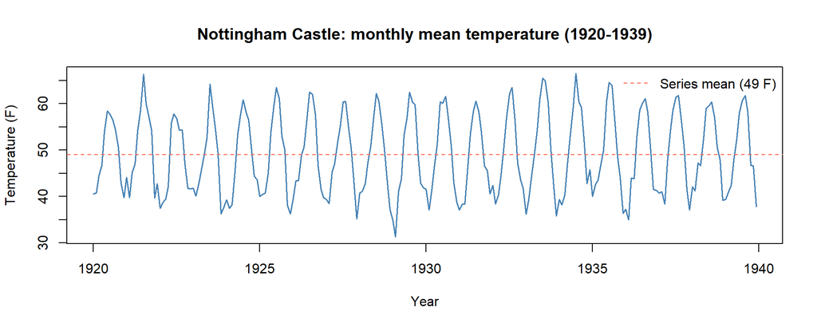

```r
plot(nottem,
     main = "Nottingham Castle: monthly mean temperature (1920-1939)",
     ylab = "Temperature (F)",
     xlab = "Year",
     col  = "steelblue",
     lwd  = 1.5)
abline(h   = mean(temp_data),
       col = "tomato",
       lty = 2,
       lwd = 1.2)
legend("topright",
       legend = paste0("Series mean (", round(mean(temp_data), 1), " F)"),
       col = "tomato", lty = 2, bty = "n")
```

The series shows a clear and consistent seasonal cycle — cold winters around 35F, warm summers around 65F — repeating every 12 months across 20 years. This regularity is exactly what separates good imputation methods from poor ones: a method that understands seasonality will recover missing winter values as cold, not as the annual mean of ~49F.

## 3. Running the benchmark

We test four methods that represent increasing levels of sophistication:

- `na.mean` — replaces every missing value with the series mean
- `na.locf` — carries the last observed value forward
- `na.approx` — linear interpolation between surrounding values
- `na.interp` — seasonal decomposition-aware interpolation

```r
methods_to_test <- c("na.mean", "na.locf", "na.approx", "na.interp")

results <- impute_errors(
  dataIn          = temp_data,
  smps            = "mcar",
  methods         = methods_to_test,
  missPercentFrom = 10,
  missPercentTo   = 50,
  interval        = 10
)

print(results)
```

```
## $Parameter
## [1] "rmse"
##
## $MissingPercent
## [1] 10 20 30 40 50
##
## $na.mean
## [1] 2.711743 3.915287 4.659677 5.473199 6.079196
##
## $na.locf
## [1] 1.826351 2.795470 4.032509 4.830674 6.656972
##
## $na.approx
## [1] 0.9305737 1.4908476 1.9056885 2.8530802 3.5215271
##
## $na.interp
## [1] 0.9305737 1.4908476 1.9056885 2.8530802 3.5215271
```

## 4. Visualising the results

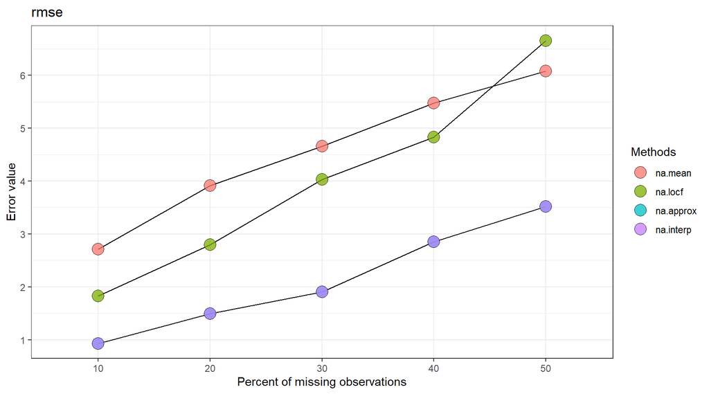

```r
plot_errors(results, plotType = "line")
```

## 5. Seeing the imputation at 50% missingness

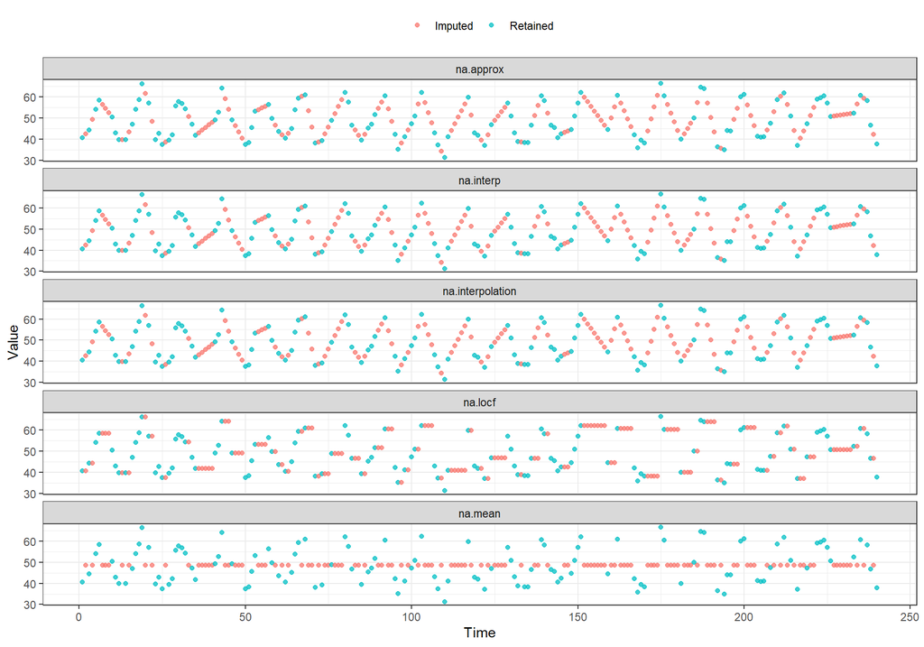

```r
plot_impute(dataIn = temp_data, missPercent = 50)
```

## 6. How much better is the best method?

```r
rmse_at_30 <- data.frame(
  method = methods_to_test,
  rmse   = round(c(results$na.mean[3],
                   results$na.locf[3],
                   results$na.approx[3],
                   results$na.interp[3]), 3)
)
rmse_at_30 <- rmse_at_30[order(rmse_at_30$rmse), ]
rmse_at_30$times_worse <- round(rmse_at_30$rmse / min(rmse_at_30$rmse), 2)
print(rmse_at_30)
```

```
##      method  rmse times_worse
## 3 na.approx 1.906        1.00
## 4 na.interp 1.906        1.00
## 2   na.locf 4.033        2.12
## 1   na.mean 4.660        2.44
```

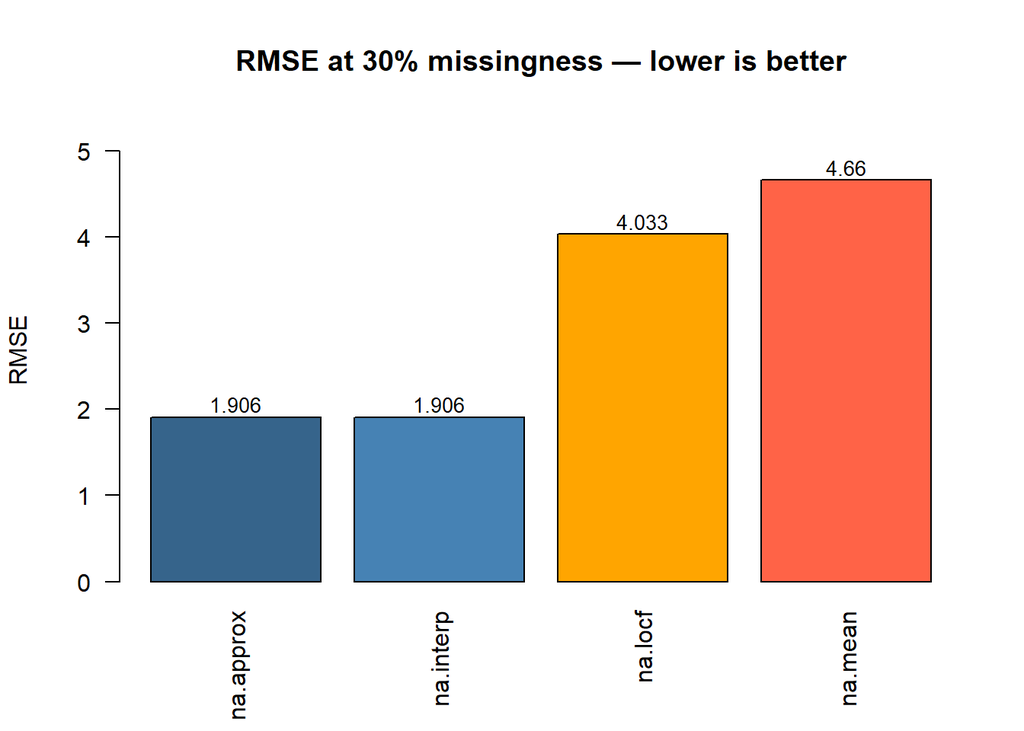

```r
colors <- c("na.interp" = "steelblue", "na.approx" = "steelblue4",
            "na.locf"   = "orange",    "na.mean"   = "tomato")

bp <- barplot(rmse_at_30$rmse,
              names.arg = rmse_at_30$method,
              col       = colors[rmse_at_30$method],
              main      = "RMSE at 30% missingness — lower is better",
              ylab      = "RMSE",
              ylim      = c(0, max(rmse_at_30$rmse) * 1.15),
              las       = 2)
text(bp, rmse_at_30$rmse + 0.15,
     labels = rmse_at_30$rmse, cex = 0.85)
```

## 7. Conclusion

`imputeTestbench` makes this comparison reproducible and systematic — running a rigorous multi-method benchmark takes just a few lines of code.